# Wikipedia’s content evaluation through multidimensional indices

André M. Rodeguero Stefanuto

2026-07/07

# Step 1: Loading packages and datasets into R ecosystem

We used following packages and datasets during the analysis. They must be loaded into R ecosystem.

```r
#If the packages are not installed, use "install.packages("package_name")" before retrieving them;
library(tidyverse)
library(corrplot)
library(ggh4x)
library(Hmisc)
library(psych)
library(ggalluvial)
library(broom)
library(viridis)
library(gridExtra)
library(cowplot)
library(flextable)
library(svglite)
library(officer)
```

```r
#In this analysis, the datasets must be locally downloaded.  They are also available in the open repository;
wiki_diseases <- read.csv("./data/input/wiki_diseases.csv", header = TRUE)
dis_references <- read.csv("./data/input/art_references.csv", header = TRUE)
```

# Step 2: Organizing the data

After loading the datasets, we grouped the data by disease and language editions containing articles within the target categories. We then aggregated them at the language level by summing word count, images, intrawiki links, sections, unique editors, total edits, and references across all articles in that language. For the last-edit-date variable, we computed the mean year across articles, then subtracted this from the year of data collection to obtain “time since last edit” (TSLE), in years.

```r
#First of all, we need to group the data in each disease and language and, then, sum the metrics in each one of them.
grouped_data <- wiki_diseases |>
  select(-category) |>
  group_by(disease, language) |>
  summarise(
    # 1) Sum of numeric variables
    across(
      c(words, images, intrawikis, sections, total_edits, unique_editors),
      sum,
      .names = "{.col}"
    ),

    # 2) Calculating "Year" means
    across(last_edit,
      ~ mean(year(ymd_hms(.x)), na.rm = TRUE, digits = 0),
      .names = "m_{.col}"
    ),

    .groups = "drop"
  ) |>
  mutate(
    tsle = round(year(today()-1) - m_last_edit, 3)
  ) |>
  select(-c(m_last_edit))
```

# Step 3: Evaluating patterns within the data

We first assessed relationships among variables using Pearson’s and Spearman’s correlation coefficients, coefficients to evaluate internal structure and to check for both linear and non-linear associations within each dimension. Then, we performed a Mann-Whitney-Wilcoxon test, between Parkinson’s and Alzheimer’s diseases data across all eight variables to compare their distribution*. In addition to this last test, we also calculated the medians to describe the central tendency of those distributions.

*Mann-Whitney-Wilcoxon and medians calculation scripts are presented in further steps, as they were performed over the full version of the dataset, which contains all textual, editorial, and referential base variables.

```r
#Pearson correlation index
corrtext_pears <- grouped_data |>
  select(disease, words, images, intrawikis, sections) |>
  group_by(disease) |>
  summarise(
    corr = list(cor(across(everything()), method = "pearson"))
    )

#corrtext_pears$corr[1] #Alzheimer's Disease
#corrtext_pears$corr[2] #Parkinson's Disease

#Significance index for Pearson's correlation
text_pears_pindex <- grouped_data |>
        select(disease, words, images, intrawikis, sections) |>
      group_by(disease) |>
      summarise(
        p_index = list(
          rcorr(as.matrix(across(everything())), type = "pearson")$P
        ),
        .groups = "drop"
      )
#text_pears_pindex$p_index[1] #Alzheimer's Disease
#text_pears_pindex$p_index[2] #Parkinson's Disease
```

```r
#Spearman correlation index
corrtext_spear <- grouped_data |>
  select(disease, words, images, intrawikis, sections) |>
  group_by(disease) |>
  summarise(
    corr = list(cor(across(everything()), method = "spearman"))
    )

#corrtext_spear$corr[1] #Alzheimer's Disease
#corrtext_spear$corr[2] #Parkinson's Disease

#Significance index for Spearman's correlation
text_spearm_pindex <- grouped_data |>
      select(disease, words, images, intrawikis, sections) |>
      group_by(disease) |>
      summarise(
        p_index = list(
          rcorr(as.matrix(across(everything())), type = "spearman")$P
        ),
        .groups = "drop"
      )

#text_spearm_pindex$p_index[1] #Alzheimer's Disease
#text_spearm_pindex$p_index[2] #Parkinson's Disease
```

```r
#Pearson correlation index
corredits_pears <- grouped_data |>
  select(disease, unique_editors, total_edits, tsle) |>
  group_by(disease) |>
  summarise(
    corr = list(cor(across(everything()), method = "pearson"))
    )

#corredits_pears$corr[1] #Alzheimer's Disease
#corredits_pears$corr[2] #Parkinson's Disease

#Significance index for Pearson correlation
edits_pears_pindex <- grouped_data |>
        select(disease, unique_editors, total_edits) |>
      group_by(disease) |>
      summarise(
        p_index = list(
          rcorr(as.matrix(across(everything())), type = "pearson")$P
        ),
        .groups = "drop"
      )
#edits_pears_pindex$p_index[1] #Alzheimer's Disease
#edits_pears_pindex$p_index[2] #Parkinson's Disease
```

```r
#Spearman correlation index
corredits_spear <- grouped_data |>
  select(disease, unique_editors, total_edits, tsle) |>
  group_by(disease) |>
  summarise(
    corr = list(cor(across(everything()), method = "spearman"))
    )

#corredits_spear$corr[1] #Alzheimer's Disease
#corredits_spear$corr[2] #Parkinson's Disease

#Significance index for Spearman correlation
edits_spearm_pindex <- grouped_data |>
      select(disease, unique_editors, total_edits) |>
      group_by(disease) |>
      summarise(
        p_index = list(
          rcorr(as.matrix(across(everything())), type = "spearman")$P
        ),
        .groups = "drop"
      )

#edits_spearm_pindex$p_index[1] #Alzheimer's Disease
#edits_spearm_pindex$p_index[2] #Parkinson's Disease
```

# Step 4: Preparing Multidimensional Content Index (Multcoin) intermediate/dimensional instances

After grouping all variables by language for both diseases, we aggregated them into three dimension-specific indices (textual, editorial, referential), using equal weighting across variables and dimensions. Within each dimension, variables were ranked in descending order, except TSLE, which was ranked in ascending order so that lower time-since-last-edit values received higher ranks; tied values were fully preserved.

```r
#Creating index based on the sums of target variables.
textindex_data <- grouped_data |>
  pivot_longer(cols = c(words, images, intrawikis, sections), names_to = "variable",
               values_to = "value") |>
  group_by(disease, variable) |>
  mutate(
    rank = {
      r <- rank(-value, ties.method = "min")
      match(r, sort(unique(r)))
    }
  ) |>
  ungroup() |>
  pivot_wider(
    names_from = variable,
    values_from = c(value, rank),
    names_glue = "{variable}_{.value}") |>
  rowwise() |>
  mutate(total_text_rank = sum(c_across(ends_with("_rank")))) |>
  ungroup() |>
  group_by(disease) |>
  mutate(
    textual_index = {
      r <- rank(total_text_rank, ties.method = "min")
      match(r, sort(unique(r)))
    }
  ) |>
  ungroup() |>
  select(-c(words_value, images_value, intrawikis_value, sections_value, total_text_rank))
```

```r
#Next, we need to create a edits index. This steps must be executed after the textual index;
editindex_data <- textindex_data |>
  select(-c(words_rank, sections_rank, images_rank, intrawikis_rank)) |>
    pivot_longer(cols = c(unique_editors, total_edits, tsle), names_to = "variable",
                 values_to = "value") |>
  group_by(disease, variable) |>
  mutate(
    rank = {
      score <- if_else(
        variable %in% "tsle",
        value,      # lower values → lower rankings
        -value      # higher values → higher rankings
      )
      r <- rank(score, ties.method = "min")
      match(r, sort(unique(r)))
    }
  ) |>
  ungroup() |>
  pivot_wider(
    names_from = variable,
    values_from = c(value, rank),
    names_glue = "{variable}_{.value}") |>
  rowwise() |>
  mutate(final_edits_rank = sum(c_across(c("unique_editors_rank", "total_edits_rank",
                                           "tsle_rank")))) |>
  ungroup() |>
  group_by(disease) |>
  mutate(
    edits_index = {
      r <- rank(final_edits_rank, ties.method = "min")
      match(r, sort(unique(r)))
    }
  ) |>
  ungroup() |>
  select(-c(final_edits_rank, unique_editors_value, total_edits_value, tsle_value,
            unique_editors_rank, total_edits_rank, tsle_rank))
```

```r
#Let's count, independently of the year, the number of references used in each language and disease.
ref_variables <- dis_references |>
  select(-c(category, reference, cctld, doi, pmid)) |>
  mutate(year = na_if(year, 0)) |>
  group_by(disease, language) |>
    summarise(
      n = n()
        ) |>
  arrange(disease, desc(n)) |>
  rename(ref_count = n)
```

```r
#Since references are in a different dataset, we need to merge them. Some languages, in each disease, doesn't have any references at all and are no accounted in the dataset. Therefore, the observations are accounted as 'NA'. During the ranking in the next chunk, every NA will be assign the lower position.
merged_refindex <- full_join(ref_variables, editindex_data,
                           by = c("disease", "language")) |>
                 arrange(disease) |>
                 select(disease, language, ref_count,
                        everything()) |>
                 mutate(ref_count = replace_na(ref_count, 0))
```

```r
refindex_data <- merged_refindex |>
  select(disease, language, ref_count, textual_index, edits_index) |>
  pivot_longer(
    cols = c(ref_count),
    names_to = "variable",
    values_to = "value"
  ) |>
  group_by(disease, variable) |>
    mutate(
      rank = {
        score <- if_else(
          is.na(value),
          Inf,
            if_else(
              variable %in% "tsle",
              value,
              -value
            )
        )
        r <- rank(score, ties.method = "min")
        match(r, sort(unique(r)))
      }
    ) |>
  ungroup() |>
  pivot_wider(
    names_from = variable,
    values_from = c(value, rank),
    names_glue = "{variable}_{.value}"
  ) |>
  rowwise() |>
  ungroup() |>
  group_by(disease) |>
  mutate(
    ref_idx = {
      r <- rank(ref_count_rank, ties.method = "min", na.last = TRUE)
      match(r, sort(unique(r)))
    }
  ) |>
  ungroup()
```

```r
#After this process, we can set place to the final dimensional indices, without their intermediary results and evaluation;

all_index_data <- refindex_data |>
  select(
    -ends_with("_value"),
    -ends_with("_rank")
  )
names(all_index_data) <- c("disease", "language", "txt_idx", "edt_idx", "ref_idx")
```

# Step 5: Calculating Multidimensional Content Index (Multcoin) and Multidimensional Stability Index (Multstabin)

Based on the five-class rating of each dimensional index (textual, editorial, referential), we measured content stability for each language as follows: observations falling in the same class across all three indices received a “High” (H) stability classification; observations in which two of three classifications coincided received a “Medium” (M) classification; and observations in which all three classifications differed received a “Low” (L) classification.

```r
final_dataset <- all_index_data |>
    group_by(disease) |>

  #Creating normalized (between 0 and 1) dimensional indexes
  mutate(
    nm_txt = round(1 - (txt_idx - min(txt_idx)) / (max(txt_idx) - min(txt_idx)), 2),
    nm_edt = round(1 - (edt_idx - min(edt_idx)) / (max(edt_idx) - min(edt_idx)), 2),
    nm_ref = round(1 - (ref_idx - min(ref_idx)) / (max(ref_idx) - min(ref_idx)), 2)
  ) |>

  #Creating classes from 1, lower, to 5, higher, across the normalized indexes
    mutate(
    parc_txt = cut(nm_txt, breaks = seq(0, 1, length.out = 6),
                  labels = 1:5, include.lowest = TRUE),
    parc_edt = cut(nm_edt, breaks = seq(0, 1, length.out = 6),
                  labels = 1:5, include.lowest = TRUE),
    parc_ref = cut(nm_ref, breaks = seq(0, 1, length.out = 6),
                  labels = 1:5, include.lowest = TRUE)
  ) |>
    select(disease, language, txt_idx, nm_txt, parc_txt, edt_idx, nm_edt, parc_edt, ref_idx, nm_ref, parc_ref) |>

   # Creating a final index, based on arithmetic means of the three dimensional indexes
    mutate(
      multcoin = round((nm_txt + nm_edt + nm_ref)/3, 2)
    ) |>

    mutate(
      parc_multcoin = cut(multcoin, breaks = seq(0, 1, length.out = 6),
                         labels = 1:5, include.lowest = TRUE)
    ) |>

    mutate(
      class_multcoin = case_when(
        parc_multcoin == 1 ~ "Very Poor",
        parc_multcoin == 2 ~ "Poor",
        parc_multcoin == 3 ~ "Regular",
        parc_multcoin == 4 ~ "Rich",
        parc_multcoin == 5 ~ "Very Rich"
      )
    ) |>

  # Creating a stability index based on the previous classes from 1 to 5.
    group_by(disease)  |>
    arrange(disease, desc(multcoin)) |>
    ungroup() |>
    mutate(
    multstabin = case_when(
      parc_txt == parc_edt & parc_edt == parc_ref ~ "h",
      parc_txt == parc_edt | parc_txt == parc_ref | parc_edt == parc_ref ~ "m", TRUE ~ "l"
    )
  ) |>
    select(disease, language, multstabin, everything())
```

# Step 6: Organizing the resulting dataset

```r
#This version includes both final indices and intermediary results, including the initial variables.
full_dataset <- final_dataset |>
  full_join(grouped_data, by = c("disease", "language")) |>
  full_join(merged_refindex, by = c("disease", "language")) |>
  select(disease, language, multstabin,
         words, images, intrawikis, sections,
         total_edits, unique_editors, tsle,
         ref_count, ref_idx, nm_ref, parc_ref,
         txt_idx, nm_txt, parc_txt, edt_idx, nm_edt, parc_edt, ref_idx, nm_ref, parc_ref, multcoin, parc_multcoin)

write_csv(full_dataset, "./data/output/results_parkalz_article.csv")
```

# Step 7: Performing Mann-Whitney-Wilcoxon test

Mann-Whitney-Wilcoxon test was performed across the eight base variables and over the full version of the dataset. The test results, as the medians, minimums and maximums composed a summary of the data.

```r
mann_med_data <- full_dataset |>
  select(disease, words, images, intrawikis, sections,
         total_edits, unique_editors, tsle,
         ref_count) |>
  pivot_longer(
    cols = -disease,
    names_to = "variable",
    values_to = "value"
  ) |>
  group_by(variable) |>
  summarise(
    # Performing Mann-Whitney-Wilcoxon test
    test = list(
      wilcox.test(value ~ disease, exact = FALSE)
    ),
    # Organizing data summary
    alz_summary = {
      s <- summary(value[disease == "Alzheimer"])
      paste0(round(s["Median"], 1), " (", round(s["Min."], 1), "–", round(s["Max."], 1), ")")
    },
    park_summary = {
      s <- summary(value[disease == "Parkinson"])
      paste0(round(s["Median"], 1), " (", round(s["Min."], 1), "–", round(s["Max."], 1), ")")
    },
    .groups = "drop"
  ) |>
  mutate(
    tidy = map(test, tidy)
  ) |>
  unnest(tidy) |>
  select(variable, p.value, alz_summary, park_summary)
```

# Step 8: Data visualization

## Step 8.1: Long version of data

```r
# Organizing a long version of the data set, with each variable-language-disease observation representing a row.
vars_long_data <- full_dataset |>
  select(disease, language, words, images, intrawikis, sections,
         total_edits, unique_editors, tsle,
         ref_count) |>
    pivot_longer(
    cols = -c(disease, language),
    names_to = "variable",
    values_to = "value"
  )
```

## Step 8.2: Graphic 1 - Distribution of individual variables

```r
var_names <- c(
  "images" = "Images",
  "intrawikis" = "Intrawikis",
  "tsle" = "TSLE (years)",
  "ref_count" = "References",
  "sections" = "Sections",
  "total_edits" = "Total Edits",
  "unique_editors" = "Unique Editors",
  "words" = "Words"
)

plot_trim <- vars_long_data |>
  group_by(variable) |>
  # Filtering the graph from 0 to 95% as the top 5% outliers make the graphics impractible
  filter(
    value <= quantile(value, 0.95, na.rm = TRUE)
  ) |>
  ungroup() |>
  # Defining factor levels for labeling
  mutate(
    disease = factor(
      disease,
      levels = c("Parkinson", "Alzheimer")
    ),
    label_disease = factor(
      disease,
      labels = c("Parkinson's Disease", "Alzheimer's Disease")
    ),
    variable = factor(
      variable,
      levels = c("images", "intrawikis", "sections", "words",
                 "tsle", "total_edits", "unique_editors",
                 "ref_count")
    )
  )

# Defining the labels
labels_names <- c("Alzheimer" = "Alzheimer's Disease",
                  "Parkinson" = "Parkinson's Disease")
```

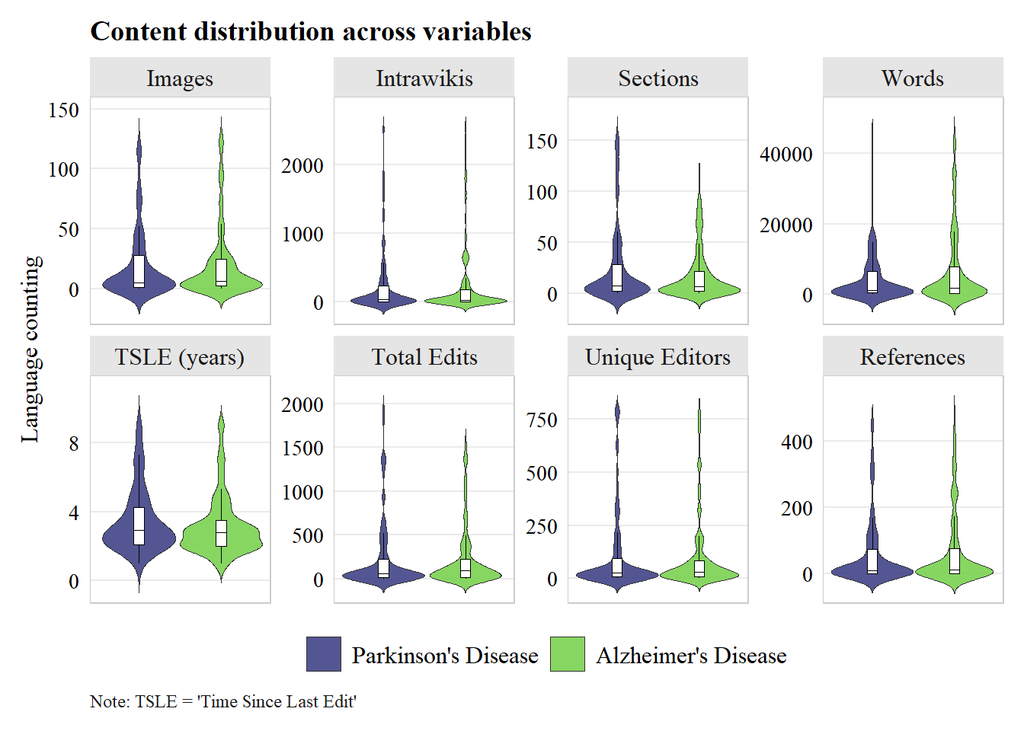

```r
gg_isovariable <- ggplot(plot_trim, aes(x = disease, y = value, fill = disease)) +
  geom_violin(
    width = 1,
    position = position_dodge(width = 0.8),
    trim = FALSE,
    alpha = 0.9,
    linewidth = .2
  ) +
  geom_boxplot(
    width = 0.125,
    alpha = 1,
    position = position_dodge(width = 0.8),
    outlier.shape = NA,
    color = "black",
    fill = "white",
    lwd = .1
  ) +
  facet_wrap(
    ~ variable,
    scales = "free_y",
    ncol = 4,
    labeller = labeller(variable = var_names)
  ) +
  scale_fill_viridis(discrete = TRUE, labels = labels_names, begin = 0.2, end = 0.8) +
  scale_y_continuous(expand = expansion(mult = c(0.05, 0.1))) +
  labs(
    title = "Content distribution across variables",
    subtitle = NULL,
    y = "Language counting",
    caption = "Note: TSLE = 'Time Since Last Edit'",
    fill = NULL                                             # <-- título da legenda
  ) +
  theme_minimal(base_family = "serif") +
  theme(
    # Legend
    legend.position      = "bottom",
    legend.justification = "center",
    legend.title         = element_blank(),
    legend.text          = element_text(size = 12),
    # Grid
    panel.grid.minor = element_blank(),
    panel.grid.major.x = element_blank(),
    # Panels border
    panel.border = element_rect(color = "grey80", fill = NA, linewidth = 0.5),
    # Axis titles
    axis.title.y = element_text(size = 12, color = "black"),
    axis.title.x = element_blank(),
    axis.text.x  = element_blank(),
    axis.ticks.x = element_blank(),
    axis.text.y  = element_text(size = 11, color = "black"),
    # Panels titles (strip)
    strip.text       = element_text(size = 12),
    strip.background = element_rect(fill = "grey90", color = NA),
    # Title and subtitle
    plot.title    = element_text(size = 14, face = "bold", color = "black"),
    # Caption
    plot.caption  = element_text(size = 9,  color = "gray10", hjust = 0),
    # Margins
    plot.margin = margin(10, 10, 10, 10)
  )

gg_isovariable
```

```r
# Exporting as .svg file for further editing
#svg("graph_isolated_variables.svg", width = 8, height = 4)
#print(gg_isovariable)
#dev.off()
```

## Step 8.3: Statistics and data summary - table exporting

```r
mann_med_table <- mann_med_data |>
  mutate(variable = var_names[variable]) |>
  mutate(p.value = round(p.value, 3))
names(mann_med_table) <- c("Variable", "P-value", "Summary Alzheimer", "Summary Parkinson")

# 1. Building the table
ft <- flextable(mann_med_table) |>
  bg(bg = "white", part = "all") |>
  border_remove() |>
  hline_top(part = "header", border = fp_border(color = "black", width = 1.5)) |>
  hline(part = "header",     border = fp_border(color = "black", width = 1.0)) |>
  hline_bottom(part = "body",border = fp_border(color = "black", width = 1.5)) |>
  add_footer_lines('Note: P-values were calculated by Mann-Whitney-Wilcoxon test; summaries are represented by "Median (Min value - Max value)".') |>
  hline_top(part = "footer", border = fp_border(color = "black", width = 1.0)) |>
  hline_bottom(part = "footer",border = fp_border(color = "black", width = 1.5)) |>
  align(j = 1,   align = "left",   part = "all") |>
  align(j = 2:4, align = "left", part = "all") |>
  font(fontname = "Times New Roman", part = "all") |>
  fontsize(size = 12, part = "body") |>
  fontsize(size = 12, part = "header") |>
  fontsize(size = 11, part = "footer") |>
  italic(part = "footer") |>
  bold(part = "header") |>
  padding(padding.top    = 3.2, padding.bottom = 3.2,
          padding.left   = 4, padding.right  = 4, part = "all") |>
  autofit()
ft
```

| Variable | P-value | Summary Alzheimer | Summary Parkinson |
| --- | --- | --- | --- |
| Images | 0.862 | 7 (0–558) | 8 (0–456) |
| Intrawikis | 0.677 | 26 (0–23185) | 35 (0–36647) |
| References | 0.496 | 15 (0–3477) | 10 (0–2403) |
| Sections | 0.508 | 7 (0–709) | 8 (0–563) |
| Total Edits | 0.522 | 101 (1–28189) | 65 (1–25679) |
| TSLE (years) | 0.267 | 3 (1–13) | 3 (1–13) |
| Unique Editors | 0.688 | 37 (1–11523) | 30 (1–10040) |
| Words | 0.771 | 2066 (8–300326) | 1322 (2–267508) |

Note: P-values were calculated by Mann-Whitney-Wilcoxon test; summaries are represented by "Median (Min value - Max value)".

```r
# Exporting as text to final formatting
#save_as_docx(ft, path = "statistics_table.docx")
```

## Step 8.4: Graphic 2 - Stacked bar plot Multstabin vs Multcoin

```r
groups_count <- final_dataset |>
  group_by(disease, parc_multcoin, multstabin) |>
  summarise(count = n(), .groups = "drop") |>
  complete(disease, parc_multcoin, multstabin, fill = list(valor = 0)) |>
  # Defining factor levels for labeling and ordering
  mutate(
    label_axis = factor(
      parc_multcoin,
      levels = rev(c(5, 4, 3, 2, 1)),
      labels = rev(c("VR", "Ri", "Re", "Po", "VP"))
    ),
    label_graph = factor(
      multstabin,
      levels = c("h", "m", "l"),
      labels = c("High", "Median",
                 "Low")
    ),
    disease = factor(
      disease,
      levels = c("Parkinson", "Alzheimer"),
      labels = c("Parkinson's Disease", "Alzheimer's Disease")
    )
  )
```

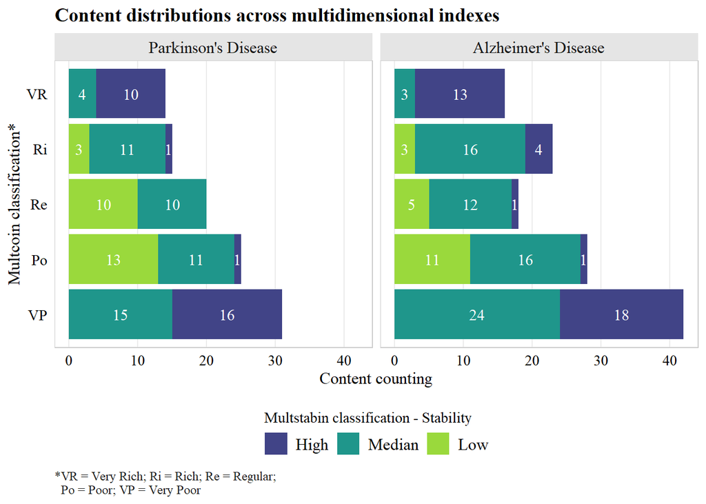

```r
gg_count <- ggplot(groups_count, aes(x = label_axis, y = count, fill = label_graph)) +
  geom_col(position = "stack") +
  geom_text(
  aes(label = count),
  position = position_stack(vjust = 0.5),
  size = 4,
  color = "white"
) +
  coord_flip() +
  facet_wrap(~ disease) +
  labs(
    title = "Content distributions across multidimensional indexes",
    x = "Multcoin classification*",
    y = "Content counting",
    fill = "Multstabin classification - Stability",
    caption = "*VR = Very Rich; Ri = Rich; Re = Regular;
  Po = Poor; VP = Very Poor"
  ) +
  theme_minimal(base_family = "serif") +
  scale_fill_viridis_d(option = "viridis", begin = 0.2, end = 0.85) +
    theme(
    # Legend
    legend.position = "bottom",
    legend.title.position = "top",
    legend.text = element_text(size = 12),
    # Grid
    panel.grid.minor.x = element_blank(),
    panel.grid.minor.y = element_blank(),
    panel.grid.major.y = element_blank(),
    # Text
    axis.title.y = element_text(size = 12, color = "black"),
    axis.title.x = element_text(size = 12, color = "black"),
    axis.text.x = element_text(size = 11, color = "black"),
    axis.text.y = element_text(size = 11, color = "black"),
    plot.title = element_text(size = 14, color = "black", face = "bold"),
    strip.text = element_text(size = 12),
    plot.caption  = element_text(size = 9,  color = "gray10", hjust = 0),
    # Border
    panel.border = element_rect(color = "grey80", fill = NA, linewidth = 0.5),
    strip.background = element_rect(fill = "grey90", color = NA)
  )

gg_count
```

```r
# Exporting as .svg file for further editing
#svg("graph_counting_class.svg", width = 8, height = 4.25)
#print(gg_count)
#dev.off()
```

## Step 8.5: Graphic 3 - Parallel sets across content dimensions

```r
alluvial_data <- full_dataset |>
  group_by(disease) |>
  # Defining factor levels for labeling and ordering
  mutate(
    parc_multcoin = factor(
      parc_multcoin,
        levels = 5:1,
        labels = c("VR", "Ri", "Re", "Po", "VP")),
      parc_txt = factor(
        parc_txt,
        levels = 5:1,
        labels = c("VR", "Ri", "Re", "Po", "VP")),
      parc_edt = factor(
        parc_edt,
        levels = 5:1,
        labels = c("VR", "Ri", "Re", "Po", "VP")),
      parc_ref = factor(
        parc_ref,
        levels = 5:1,
        labels = c("VR", "Ri", "Re", "Po", "VP")),
      disease = factor(
        disease,
          levels = c("Parkinson", "Alzheimer"),
          labels = c("Parkinson's Disease", "Alzheimer's Disease"))
  ) |>
  ungroup()

alluvial_data$id <- seq_len(nrow(alluvial_data))

# Converting to "lodes" format - a long format based on subgroups of the classes.
lodes_data <- to_lodes_form(
  alluvial_data,
  axes = c("parc_txt", "parc_edt", "parc_ref"),
  id = "id"
)
```

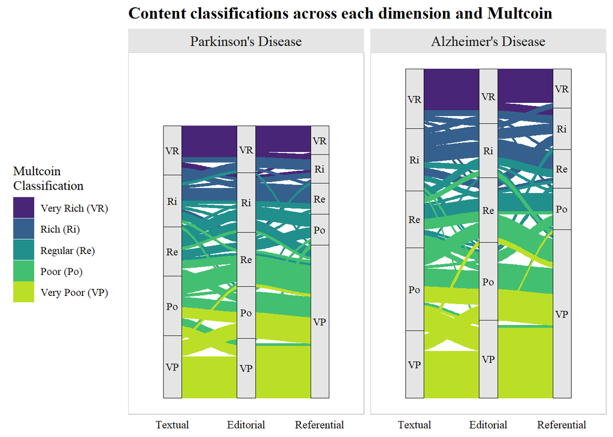

```r
parallel_gg <- ggplot(
  lodes_data,
  aes(
    x = x,
    stratum = stratum,
    alluvium = id,
    y = 1,
    fill = parc_multcoin
  )
) +
  geom_alluvium(
    aes(
      fill = parc_multcoin,
      color = parc_multcoin
    ),
    width = 0.05,
    alpha = 1,
    linewidth = 0.03,
    curve_type = "cubic"
  ) +
  geom_stratum(fill = "grey90", color = "black", show.legend = FALSE, width = .25, size = .05) +
  geom_text(stat = "stratum", aes(label = stratum), size = 3) +
  scale_x_discrete(
    limits = c("parc_txt", "parc_edt", "parc_ref"),
    labels = c("Textual", "Editorial", "Referential")
  ) +
  scale_fill_viridis(
    discrete = TRUE,
    option = "D",
    na.translate = FALSE,
    drop = TRUE,
    labels = c("VR" = "Very Rich (VR)",
               "Ri" = "Rich (Ri)",
               "Re" = "Regular (Re)",
               "Po" = "Poor (Po)",
               "VP" = "Very Poor (VP)"),
    begin = .1,
    end =.9
  ) +
  scale_color_viridis(
    discrete = TRUE,
    option = "D",
    na.translate = FALSE,
    guide = "none",
    begin = .1,
    end = .9
  ) +
  facet_wrap(~ disease, ncol = 2) +
  theme_minimal() +
  labs(
    title = "Content classifications across each dimension and Multcoin",
    y = NULL,
    x = NULL
  ) +
  guides(
    fill = guide_legend(
      nrow = 5,
      title = "Multcoin \nClassification",
      title.position = "top"
    )
  ) +
  theme_minimal(base_family = "serif") +
  theme(
    # Legend
    legend.position = "left",
    # Grid
    panel.grid.minor.x = element_blank(),
    panel.grid.minor.y = element_blank(),
    panel.grid.major.y = element_blank(),
    panel.grid.major.x = element_blank(),
    # Text
    axis.title.y = element_blank(),
    axis.title.x = element_blank(),
    axis.text.x = element_text(size = 9, color = "black"),
    axis.text.y = element_blank(),
    strip.text = element_text(size = 12),
    plot.title = element_text(color = "black", size = 14, face = "bold"),
    plot.caption = element_text(hjust = 0, size = 9),
    # Border
    panel.border = element_rect(color = "grey80", fill = NA, linewidth = 0.5),
    strip.background = element_rect(fill = "grey90", color = NA)
  )

parallel_gg
```

```r
# Exporting as .svg file for further editing
#svg("graph_parallel_sets.svg", width = 8, height = 4)
#print(parallel_gg)
#dev.off()
```